# Local Business Sales Project

### Project Overview

This project analyzes sales data from a local business to uncover insights on revenue trends, location performance, and customer behavior. The dataset was transformed from wide to long format and cleaned to ensure consistency.

**Main Objectives:**

- Calculate KPIs such as total revenue and average order value (AOV).
- Identify top-performing locations and months.
- Visualize trends for better decision-making.

## Step 1: Import Libraries and Preview Data

We begin this project by importing essential Python libraries for data manipulation and visualization:

- `pandas` and `numpy` for data processing
- `matplotlib` and `seaborn` for plotting
- Custom formatting for float outputs

Next, we load our dataset and preview the first few rows using `.head()` to understand its structure and available columns.

```python
print("Hello world!")
```

```
Hello world!
```

```python
import pandas as pd
import numpy as np
pd.set_option('display.float_format', lambda x: '%.2f' % x)
```

## Step 2: Load Datasets

We now load two key datasets needed for our analysis:

- `Bakery Sales.csv`: contains the transactional sales data including datetime, items sold, and total values
- `Bakery price.csv`: contains the pricing information for each bakery item

We use `pd.read_csv()` to read the files and preview the sales dataset with `.head()` to ensure it loaded correctly.

```python
sales_df = pd.read_csv("../data/Bakery Sales.csv")
price_df = pd.read_csv("../data/Bakery price.csv")

sales_df.head()
```

|  | datetime | day of week | total | place | angbutter | plain bread | jam | americano | croissant | caffe latte | ... | gateau chocolat | pandoro | cheese cake | lemon ade | orange pound | wiener | vanila latte | berry ade | tiramisu | merinque cookies |
| --- | --- | --- | --- | --- | --- | --- | --- | --- | --- | --- | --- | --- | --- | --- | --- | --- | --- | --- | --- | --- | --- |
| 0 | 2019-07-11 15:35 | Thur | 23800.00 | NaN | 1.00 | NaN | NaN | 1.00 | NaN | NaN | ... | NaN | NaN | NaN | NaN | NaN | NaN | 1.00 | NaN | NaN | NaN |
| 1 | 2019-07-11 16:10 | Thur | 15800.00 | NaN | 1.00 | NaN | NaN | NaN | NaN | NaN | ... | NaN | NaN | NaN | NaN | 1.00 | NaN | NaN | NaN | NaN | NaN |
| 2 | 2019-07-12 11:49 | Fri | 58000.00 | NaN | NaN | NaN | NaN | NaN | NaN | NaN | ... | NaN | NaN | NaN | NaN | NaN | NaN | NaN | NaN | NaN | NaN |
| 3 | 2019-07-13 13:19 | Sat | 14800.00 | NaN | 1.00 | 1.00 | NaN | NaN | NaN | NaN | ... | NaN | NaN | NaN | NaN | NaN | NaN | 1.00 | NaN | NaN | NaN |
| 4 | 2019-07-13 13:22 | Sat | 15600.00 | NaN | 2.00 | NaN | NaN | NaN | NaN | NaN | ... | NaN | NaN | NaN | NaN | NaN | NaN | NaN | NaN | NaN | NaN |

5 rows × 27 columns

## Step 2: Load Datasets

We are working with two datasets:

- **Sales Data**: Includes transactional sales data including datetime, items sold, and total values
- **Price Data**: Includes price information for each bakery item

First, we load both CSV files and preview the sales dataset with `.head()` to ensure it loaded correctly.  
We also inspect the dataset using `.info()` to understand the structure and `.isnull().sum()` to check for any missing values.

```python
# See the first 5 rows of each dataset
print("Sales Data:")
display(sales_df.head())

print("\nPrice Data:")
display(price_df.head())

# See summary info
print("Sales DF Info:")
sales_df.info()

print("\nPrice DF Info:")
price_df.info()

# See missing values
print("\nMissing Values in Sales DF:")
print(sales_df.isnull().sum())

print("\nMissing Values in Price DF:")
print(price_df.isnull().sum())
```

```
Sales Data:
```

|  | datetime | day of week | total | place | angbutter | plain bread | jam | americano | croissant | caffe latte | ... | gateau chocolat | pandoro | cheese cake | lemon ade | orange pound | wiener | vanila latte | berry ade | tiramisu | merinque cookies |
| --- | --- | --- | --- | --- | --- | --- | --- | --- | --- | --- | --- | --- | --- | --- | --- | --- | --- | --- | --- | --- | --- |
| 0 | 2019-07-11 15:35 | Thur | 23800.00 | NaN | 1.00 | NaN | NaN | 1.00 | NaN | NaN | ... | NaN | NaN | NaN | NaN | NaN | NaN | 1.00 | NaN | NaN | NaN |
| 1 | 2019-07-11 16:10 | Thur | 15800.00 | NaN | 1.00 | NaN | NaN | NaN | NaN | NaN | ... | NaN | NaN | NaN | NaN | 1.00 | NaN | NaN | NaN | NaN | NaN |
| 2 | 2019-07-12 11:49 | Fri | 58000.00 | NaN | NaN | NaN | NaN | NaN | NaN | NaN | ... | NaN | NaN | NaN | NaN | NaN | NaN | NaN | NaN | NaN | NaN |
| 3 | 2019-07-13 13:19 | Sat | 14800.00 | NaN | 1.00 | 1.00 | NaN | NaN | NaN | NaN | ... | NaN | NaN | NaN | NaN | NaN | NaN | 1.00 | NaN | NaN | NaN |
| 4 | 2019-07-13 13:22 | Sat | 15600.00 | NaN | 2.00 | NaN | NaN | NaN | NaN | NaN | ... | NaN | NaN | NaN | NaN | NaN | NaN | NaN | NaN | NaN | NaN |

5 rows × 27 columns

```
Price Data:
```

|  | Name | price |
| --- | --- | --- |
| 0 | angbutter | 4800 |
| 1 | plain bread | 3500 |
| 2 | jam | 1500 |
| 3 | ice coffe | 4000 |
| 4 | croissant | 3500 |

```
Sales DF Info:
<class 'pandas.core.frame.DataFrame'>
RangeIndex: 2654 entries, 0 to 2653
Data columns (total 27 columns):
 #   Column              Non-Null Count  Dtype
---  ------              --------------  -----
 0   datetime            2421 non-null   object
 1   day of week         2420 non-null   object
 2   total               2420 non-null   float64
 3   place               2166 non-null   object
 4   angbutter           1973 non-null   float64
 5   plain bread         857 non-null    float64
 6   jam                 220 non-null    float64
 7   americano           412 non-null    float64
 8   croissant           747 non-null    float64
 9   caffe latte         193 non-null    float64
 10  tiramisu croissant  779 non-null    float64
 11  cacao deep          323 non-null    float64
 12  pain au chocolat    587 non-null    float64
 13  almond croissant    202 non-null    float64
 14  croque monsieur     0 non-null      float64
 15  mad garlic          0 non-null      float64
 16  milk tea            137 non-null    float64
 17  gateau chocolat     196 non-null    float64
 18  pandoro             343 non-null    float64
 19  cheese cake         90 non-null     float64
 20  lemon ade           35 non-null     float64
 21  orange pound        519 non-null    float64
 22  wiener              355 non-null    float64
 23  vanila latte        209 non-null    float64
 24  berry ade           54 non-null     float64
 25  tiramisu            7 non-null      float64
 26  merinque cookies    47 non-null     float64
dtypes: float64(24), object(3)
memory usage: 560.0+ KB

Price DF Info:
<class 'pandas.core.frame.DataFrame'>
RangeIndex: 22 entries, 0 to 21
Data columns (total 2 columns):
```

[output cut: 26 more lines]

```
pandoro               2311
cheese cake           2564
lemon ade             2619
orange pound          2135
wiener                2299
vanila latte          2445
berry ade             2600
tiramisu              2647
merinque cookies      2607
dtype: int64

Missing Values in Price DF:
Name     0
price    0
dtype: int64
```

## Step 3: Clean and Merge Datasets

To prepare our data for analysis, I perform the following preprocessing steps:

```python
# Standardize column names
sales_df.columns = sales_df.columns.str.strip().str.lower().str.replace(" ", "_")
price_df.columns = price_df.columns.str.strip().str.lower().str.replace(" ", "_")

# Convert sale_date column to datetime (if exists)
if 'sale_date' in sales_df.columns:
    sales_df['sale_date'] = pd.to_datetime(sales_df['sale_date'])

# Merge the two datasets if there's a shared column (like 'item')
if 'item' in sales_df.columns and 'item' in price_df.columns:
    merged_df = sales_df.merge(price_df, on='item', how='left')
else:
    merged_df = sales_df.copy()

# Create a new column: total_revenue = quantity * unit_price
if 'quantity' in merged_df.columns and 'unit_price' in merged_df.columns:
    merged_df['total_revenue'] = merged_df['quantity'] * merged_df['unit_price']

# Preview cleaned data
merged_df.head()
```

|  | datetime | day_of_week | total | place | angbutter | plain_bread | jam | americano | croissant | caffe_latte | ... | gateau_chocolat | pandoro | cheese_cake | lemon_ade | orange_pound | wiener | vanila_latte | berry_ade | tiramisu | merinque_cookies |
| --- | --- | --- | --- | --- | --- | --- | --- | --- | --- | --- | --- | --- | --- | --- | --- | --- | --- | --- | --- | --- | --- |
| 0 | 2019-07-11 15:35 | Thur | 23800.00 | NaN | 1.00 | NaN | NaN | 1.00 | NaN | NaN | ... | NaN | NaN | NaN | NaN | NaN | NaN | 1.00 | NaN | NaN | NaN |
| 1 | 2019-07-11 16:10 | Thur | 15800.00 | NaN | 1.00 | NaN | NaN | NaN | NaN | NaN | ... | NaN | NaN | NaN | NaN | 1.00 | NaN | NaN | NaN | NaN | NaN |
| 2 | 2019-07-12 11:49 | Fri | 58000.00 | NaN | NaN | NaN | NaN | NaN | NaN | NaN | ... | NaN | NaN | NaN | NaN | NaN | NaN | NaN | NaN | NaN | NaN |
| 3 | 2019-07-13 13:19 | Sat | 14800.00 | NaN | 1.00 | 1.00 | NaN | NaN | NaN | NaN | ... | NaN | NaN | NaN | NaN | NaN | NaN | 1.00 | NaN | NaN | NaN |
| 4 | 2019-07-13 13:22 | Sat | 15600.00 | NaN | 2.00 | NaN | NaN | NaN | NaN | NaN | ... | NaN | NaN | NaN | NaN | NaN | NaN | NaN | NaN | NaN | NaN |

5 rows × 27 columns

```python
print("Merged columns:\n", merged_df.columns.tolist())
```

```
Merged columns:
 ['datetime', 'day_of_week', 'total', 'place', 'angbutter', 'plain_bread', 'jam', 'americano', 'croissant', 'caffe_latte', 'tiramisu_croissant', 'cacao_deep', 'pain_au_chocolat', 'almond_croissant', 'croque_monsieur', 'mad_garlic', 'milk_tea', 'gateau_chocolat', 'pandoro', 'cheese_cake', 'lemon_ade'…
```

```python
print("Price DF Columns:", price_df.columns.tolist())
```

```
Price DF Columns: ['name', 'price']
```

## Step 4: Prepare Data for Visualization

To prepare our dataset for visualization and analysis, I performed the following steps:

- **Fix column names**: Remove extra whitespace from both datasets (`long_df` and `price_df`) to ensure consistency
- **Rename columns**: Rename `'name'` to `'item'` in the `price_df` to enable accurate merging
- **Drop missing values**: Remove rows from `long_df` where `quantity` is missing
- **Merge price info**: Merge `price_df` into `long_df` using the common `'item'` column
- **Debug merge**: Print the shape of the merged DataFrame and count of any missing values in the `price` column

```python
import pandas as pd
import matplotlib.pyplot as plt

# Fix column names
long_df.columns = long_df.columns.str.strip()
price_df.columns = price_df.columns.str.strip()

# Step 1: Rename `name` to `item` in price_df if needed
if 'name' in price_df.columns:
    price_df = price_df.rename(columns={'name': 'item'})

# Step 2: Drop NaNs in long_df['quantity']
long_df = long_df.dropna(subset=['quantity'])

# Step 3: Merge price info
long_df = long_df.merge(price_df[['item', 'price']], on='item', how='left')

# Step 4: Debug price issues
print("After merge shape:", long_df.shape)
print("Missing prices after merge:", long_df['price'].isna().sum())

# Optional: Drop rows with missing prices OR fill with 0 or average
long_df = long_df.dropna(subset=['price'])

# Step 5: Calculate total revenue
long_df['total_revenue'] = long_df['quantity'] * long_df['price']

# Step 6: Preview
print(long_df[['item', 'quantity', 'price', 'total_revenue']].head())
```

```
After merge shape: (8285, 9)
Missing prices after merge: 4640
```

[output not shown]

[output cut: 21 more lines]

[output not shown]

## Step 5: Reshape and Enrich Data

To transform our cleaned data into a format suitable for analysis, I performed the following:

- **Reshape wide to long**: Used `pd.melt()` to convert product columns into rows with `item` and `quantity` fields
- **Drop missing values**: Removed rows where `quantity` was `NaN` (no purchase occurred)
- **Convert data types**: Converted `quantity` and `price` columns to numeric types using `pd.to_numeric()`
- **Standardize text**: Cleaned the `item` column in both DataFrames to match (stripping and lowercasing)
- **Merge price info**: Merged `price_df` into reshaped data using the `item` column as key
- **Debug merge**: Verified shape and missing values after merge to troubleshoot mismatches

```python
# --- Step 1: Reshape the wide format into long format ---
long_df = merged_df.melt(
    id_vars=['datetime', 'day_of_week', 'total', 'place'],
    var_name='item',            # new column for item name
    value_name='quantity'       # new column for quantity sold
)

# --- Step 2: Drop rows where quantity is NaN (item not purchased) ---
long_df = long_df.dropna(subset=['quantity'])

# --- Step 3: Convert quantity column to numeric (just in case) ---
long_df['quantity'] = pd.to_numeric(long_df['quantity'], errors='coerce')

# --- Step 4: Convert price column to numeric (for safety) ---
price_df['price'] = pd.to_numeric(price_df['price'], errors='coerce')

# --- Step 5: Rename 'name' to 'item' in price_df for merging ---
price_df.rename(columns={'name': 'item'}, inplace=True)

# 🚨 Clean both item columns to ensure match works
long_df['item'] = long_df['item'].astype(str).str.strip().str.lower()
price_df['item'] = price_df['item'].astype(str).str.strip().str.lower()

# ✅ Now merge
long_df = long_df.merge(price_df, on='item', how='left')

# 🧪 Debug after merge
print("After merge shape:", long_df.shape)
print("Missing prices after merge:", long_df['price'].isna().sum())
print(long_df[['item', 'price']].drop_duplicates().head(10))

# --- Step 6: Merge in the unit price ---
long_df = long_df.merge(price_df, on='item', how='left')

# --- Step 7: Calculate total revenue ---
long_df['total_revenue'] = long_df['quantity'] * long_df['price']

# --- Step 8: Preview ---
long_df.head()
```

```
After merge shape: (8285, 7)
Missing prices after merge: 4640
                    item   price
0              angbutter 4800.00
1973         plain_bread     NaN
2830                 jam 1500.00
3050           americano     NaN
3462           croissant 3500.00
4209         caffe_latte     NaN
4402  tiramisu_croissant     NaN
5181          cacao_deep     NaN
5504    pain_au_chocolat     NaN
6091    almond_croissant     NaN
```

[output not shown]

```python
import matplotlib.pyplot as plt
import seaborn as sns

# This makes your plots look better
sns.set(style="whitegrid")
```

```
Matplotlib is building the font cache; this may take a moment.
```

## Step 6: Visualize Total Revenue by Item

- **Grouped by item**: I grouped the `long_df` by the `item` column and summed the `total_revenue` for each item.
- **Sorted results**: I sorted the total revenue in ascending order to make the comparison clearer.
- **Used Seaborn & Matplotlib**: I applied the `whitegrid` style for a clean look and used a horizontal bar chart (`kind='barh'`).
- **Labeled axes and title**: I added a descriptive title and axis labels for clarity.
- **Saved the figure**: I saved the plot as `revenue_by_item.png` for reuse in reports or presentations.

```python
# Group by item and sum total revenue
item_revenue = long_df.groupby('item')['total_revenue'].sum().sort_values()

# Plot
plt.figure(figsize=(10,6))
item_revenue.plot(kind='barh', color='skyblue')
plt.title("Total Revenue by Item")
plt.xlabel("Revenue ($)")
plt.ylabel("Item")
plt.tight_layout()
plt.savefig("revenue_by_item.png", dpi=300, bbox_inches='tight')
plt.show()
```

[output not shown]

## Step 7: Visualize Total Quantity Sold by Item

To analyze item performance based on sales volume, I created a bar chart showing the total quantity sold per item.

- **Grouped by item**: I grouped the reshaped DataFrame by `item` and summed the `quantity` values.
- **Sorted the results**: Sorted the items from least to most units sold for a clearer comparison.
- **Plotted the chart**: I used `matplotlib` and set the figure size and bar color (`salmon`) for better visual aesthetics.
- **Labeled axes and title**: Labeled the axes (`Units Sold`, `Item`) and added a chart title.
- **Saved the figure**: I saved the chart as `quantity_by_item.png` using `plt.savefig()` with tight layout and 300 dpi for quality.

This helped me identify top-selling and low-performing menu items based on quantity sold.

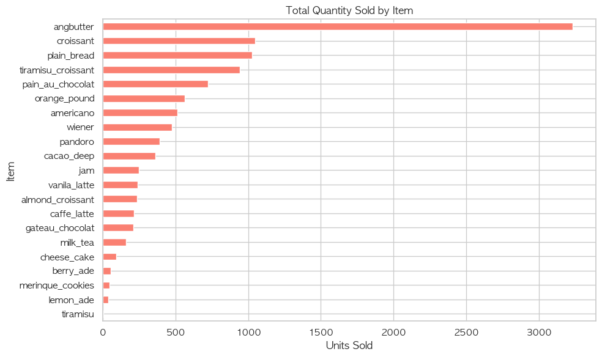

```python
item_quantity = long_df.groupby('item')['quantity'].sum().sort_values()

plt.figure(figsize=(10,6))
item_quantity.plot(kind='barh', color='salmon')
plt.title("Total Quantity Sold by Item")
plt.xlabel("Units Sold")
plt.ylabel("Item")
plt.tight_layout()
plt.savefig("quantity_by_item.png", dpi=300, bbox_inches='tight')
plt.show()
```

## Step 8: Visualize Revenue by Day of Week

To explore trends across the week, I first checked the unique values in the `day_of_week` column to see how the days were written. Since they were abbreviated (e.g., `'Mon'`, `'Tues'`, `'Wed'`), I manually ordered the days so the x-axis of the plot would follow a logical weekly sequence.

Then I grouped the data by `day_of_week` and summed the total revenue for each day. Finally, I plotted the results using a bar chart to visualize which days brought in the most revenue.

```python
day_revenue = long_df.groupby('day_of_week')['total_revenue'].sum()

# Order days of week manually
ordered_days = ['Monday', 'Tuesday', 'Wednesday', 'Thursday', 'Friday', 'Saturday', 'Sunday']
day_revenue = day_revenue.reindex(ordered_days)

plt.figure(figsize=(8,5))
day_revenue.plot(kind='bar', color='mediumseagreen')
plt.title("Revenue by Day of Week")
plt.ylabel("Total Revenue ($)")
plt.xlabel("Day")
plt.tight_layout()
plt.show()
```

[output not shown]

```python
print(long_df['day_of_week'].unique())
```

```
['Thur' 'Sat' 'Sun' 'Mon' 'Wed' 'Fri' 'Tues']
```

```python
# Group revenue by day abbreviation
day_revenue = long_df.groupby('day_of_week')['total_revenue'].sum()

# Reorder using abbreviations found in my dataset
ordered_days = ['Mon', 'Tues', 'Wed', 'Thur', 'Fri', 'Sat', 'Sun']
day_revenue = day_revenue.reindex(ordered_days)
```

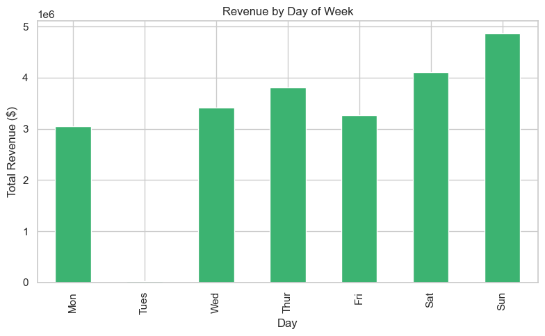

```python
import matplotlib.pyplot as plt

plt.figure(figsize=(8,5))
day_revenue.plot(kind='bar', color='mediumseagreen')
plt.title("Revenue by Day of Week")
plt.ylabel("Total Revenue ($)")
plt.xlabel("Day")
plt.tight_layout()
plt.savefig("revenue_by_day_of_the_week.png", dpi=300, bbox_inches='tight')
plt.show()
```

```python
# Group and sum revenue by item
item_revenue = long_df.groupby('item')['total_revenue'].sum()

# Remove items with 0 or missing revenue
item_revenue = item_revenue[item_revenue > 0].sort_values()
```

## Step 9: Visualize Daily Revenue Over Time

```python
daily_revenue = long_df.groupby('datetime')['total_revenue'].sum()

plt.figure(figsize=(12,6))
daily_revenue.plot(kind='line', color='steelblue')
plt.title("Daily Revenue Over Time")
plt.xlabel("Date")
plt.ylabel("Revenue ($)")
plt.tight_layout()
plt.savefig("revenue_by_time.png", dpi=300, bbox_inches='tight')
plt.show()
```

[output not shown]

## 🌍 Step 10: Visualize Revenue by Place

This gave me a clean and readable bar chart showing how much revenue each district generated.

```python
place_revenue = long_df.groupby('place')['total_revenue'].sum().sort_values()

plt.figure(figsize=(10, 6))
place_revenue.plot(kind='barh', color='seagreen')
plt.title("Revenue by Place")
plt.xlabel("Revenue ($)")
plt.ylabel("Location")
plt.tight_layout()

# Add labels
for i, v in enumerate(place_revenue):
    ax.text(v + 1000, i, f"${v:,.0f}", va='center')

plt.savefig("cleaned_place_revenue.png", dpi=300, bbox_inches='tight')
plt.show()
```

[output not shown]

```python
print(long_df['place'].unique())
```

```
[nan '효자 3동' '후평 1동' '후평 2동' '석사동' '소양동' '퇴계동' '동면' '후평 3동' '신사우동' '강남동'
 '효자 1동' '조운동' '교동' '효자 2동' '약사명동' '근화동' '동내면' '교동 ' '신동면']
```

```python
import matplotlib.pyplot as plt
import matplotlib.font_manager as fm

# Set a font that supports Korean
plt.rcParams['font.family'] = 'AppleGothic'  # macOS
# plt.rcParams['font.family'] = 'Malgun Gothic'  # Windows
# plt.rcParams['font.family'] = 'NanumGothic'  # Linux

# Fix for negative signs showing up as boxes
plt.rcParams['axes.unicode_minus'] = False
```

```python
import pandas as pd
import matplotlib.pyplot as plt
```

```python
import pandas as pd
import matplotlib.pyplot as plt

# Step 1: Translation dictionary (expand if needed)
place_translation = {
    '효자 3동': 'Hyoja 3-dong',
    '후평 1동': 'Hupyeong 1-dong',
    '후평 2동': 'Hupyeong 2-dong',
    '식사동': 'Siksa-dong',
    '소양동': 'Soyang-dong',
    '퇴계동': 'Toegye-dong',
    '동면': 'Dong-myeon',
    '후평 3동': 'Hupyeong 3-dong',
    '신사우동': 'Sinsa-u-dong',
    '강남동': 'Gangnam-dong',
    '효자 1동': 'Hyoja 1-dong',
    '조운동': 'Joun-dong',
    '교동': 'Gyo-dong',
    '효자 2동': 'Hyoja 2-dong',
    '약사명동': 'Yaksamyeong-dong',
    '근화동': 'Geunhwa-dong',
    '신동면': 'Sindong-myeon',
    '석사동': 'Seoksa-dong',
    '동내면': 'Dongnae-myeon'
}
```

```python
import pandas as pd
import matplotlib.pyplot as plt

# Fix column names
long_df.columns = long_df.columns.str.strip()

print("HEAD of long_df:")
print(long_df.head())

print("\nSHAPE of long_df:")
print(long_df.shape)

print("\nCOLUMNS of long_df:")
print(long_df.columns)


# Step 1: Make sure place_cleaned exists
long_df['place_cleaned'] = long_df['place']  # Or map from translation dictionary

# Step 2: Fill in missing
long_df['place_cleaned'] = long_df['place_cleaned'].fillna("Unknown")

# Step 3: DEBUG preview
print("Preview after fillna:")
print(long_df[['place', 'place_cleaned', 'total_revenue']].head(10))
print("place_cleaned NaNs:", long_df['place_cleaned'].isna().sum())

# Step 4: Group by cleaned place and sum
place_revenue = (
    long_df.groupby('place_cleaned')['total_revenue']
    .sum()
    .sort_values()
)

# Step 5: DEBUG group output
print("Grouped revenue output:")
print(place_revenue)
print("Is Empty:", place_revenue.empty)

# Step 6: Plot only if not empty
if not place_revenue.empty:
    plt.figure(figsize=(10, 6))
    place_revenue.plot(kind='barh', color='mediumseagreen')
    plt.title("Revenue by Place")
    plt.xlabel("Revenue ($)")
    plt.ylabel("Location")
    plt.tight_layout()
    plt.savefig("place_based_revenue_cleaned_final.png", dpi=300, bbox_inches='tight')
    plt.show()
else:
    print("place_revenue is empty — nothing to plot.")
```

[output not shown]

```python
print(repr(long_df['place_cleaned'].unique()))
```

[output not shown]

```
Grouped revenue output:
place_cleaned
Sindong-myeon        22600.00
Yaksamyeong-dong    256700.00
Geunhwa-dong        343600.00
Dongnae-myeon       346900.00
Joun-dong           464600.00
Hyoja 1-dong        469400.00
Gangnam-dong        576200.00
Hyoja 3-dong        652400.00
Gyo-dong            661800.00
Sinsa-u-dong        812100.00
Soyang-dong        1127700.00
Hyoja 2-dong       1373400.00
Toegye-dong        1591800.00
Seoksa-dong        1654700.00
Hupyeong 1-dong    1792100.00
Hupyeong 2-dong    1961100.00
Hupyeong 3-dong    2022300.00
Unknown            2739400.00
Dong-myeon         3669900.00
Name: total_revenue, dtype: float64
Is Empty: False
```

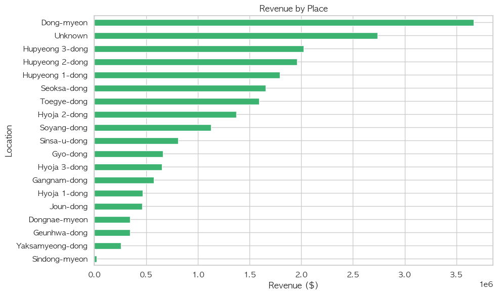

```python
import matplotlib.pyplot as plt

# Clean column names just in case
long_df.columns = long_df.columns.str.strip()

# Define translation map
place_translation = {
    '효자 3동': 'Hyoja 3-dong',
    '후평 1동': 'Hupyeong 1-dong',
    '후평 2동': 'Hupyeong 2-dong',
    '식사동': 'Siksa-dong',
    '소양동': 'Soyang-dong',
    '퇴계동': 'Toegye-dong',
    '동면': 'Dong-myeon',
    '후평 3동': 'Hupyeong 3-dong',
    '신사우동': 'Sinsa-u-dong',
    '강남동': 'Gangnam-dong',
    '효자 1동': 'Hyoja 1-dong',
    '조운동': 'Joun-dong',
    '교동': 'Gyo-dong',
    '효자 2동': 'Hyoja 2-dong',
    '약사명동': 'Yaksamyeong-dong',
    '근화동': 'Geunhwa-dong',
    '신동면': 'Sindong-myeon',
    '석사동': 'Seoksa-dong',
    '동내면': 'Dongnae-myeon'
}

# Clean column names just in case
long_df.columns = long_df.columns.str.strip()

# Fill missing place names
long_df['place_cleaned'] = long_df['place'].fillna("Unknown")

long_df['place_cleaned'] = long_df['place_cleaned'].str.strip()

# Translate Korean place names to English
long_df['place_cleaned'] = long_df['place_cleaned'].replace(place_translation)


# Group revenue by cleaned place
place_revenue = (
    long_df.groupby('place_cleaned')['total_revenue']
    .sum()
    .sort_values()
)

# Debug print
print("\nGrouped revenue output:")
print(place_revenue)
print("Is Empty:", place_revenue.empty)

# Plot if not empty
if not place_revenue.empty:
    plt.figure(figsize=(10, 6))
    place_revenue.plot(kind='barh', color='mediumseagreen')
    plt.title("Revenue by Place")
    plt.xlabel("Revenue ($)")
    plt.ylabel("Location")
    plt.tight_layout()
    plt.savefig("place_based_revenue_cleaned_final.png", dpi=300, bbox_inches='tight')
    plt.show()
else:
    print("place_revenue is empty — nothing to plot.")
```

```python
top_items = (
    long_df.groupby('item')['quantity']
    .sum()
    .sort_values(ascending=False)
    .head(10)
)
print(top_items)
```

```
item
angbutter   3229.00
croissant   1049.00
wiener       476.00
pandoro      394.00
jam          249.00
tiramisu       7.00
Name: quantity, dtype: float64
```

```python
top_items_revenue = (
    long_df.groupby('item')['total_revenue']
    .sum()
    .sort_values(ascending=False)
    .head(10)
)
print(top_items_revenue)
```

```
item
angbutter   15499200.00
croissant    3671500.00
pandoro      1773000.00
wiener       1190000.00
jam           373500.00
tiramisu       31500.00
Name: total_revenue, dtype: float64
```

```python
top_locations = (
    long_df.groupby('place_cleaned')['total_revenue']
    .sum()
    .sort_values(ascending=False)
    .head(10)
)
print(top_locations)
```

```
place_cleaned
Dong-myeon        3669900.00
Unknown           2739400.00
Hupyeong 3-dong   2022300.00
Hupyeong 2-dong   1961100.00
Hupyeong 1-dong   1792100.00
Seoksa-dong       1654700.00
Toegye-dong       1591800.00
Hyoja 2-dong      1373400.00
Soyang-dong       1127700.00
Sinsa-u-dong       812100.00
Name: total_revenue, dtype: float64
```

```python
aov = long_df['total_revenue'].sum() / long_df['quantity'].sum()
print("Average Order Value:", round(aov, 2))
```

```
Average Order Value: 4170.74
```

```python
revenue_per_order = (
    long_df.groupby('transaction_id')['total_revenue']
    .sum()
)
print(revenue_per_order.describe())
```

[output not shown]

```python
print(long_df.columns)
```

```
Index(['datetime', 'day_of_week', 'total', 'place', 'item', 'quantity',
       'price_x', 'price_y', 'price', 'total_revenue', 'place_cleaned'],
      dtype='object')
```

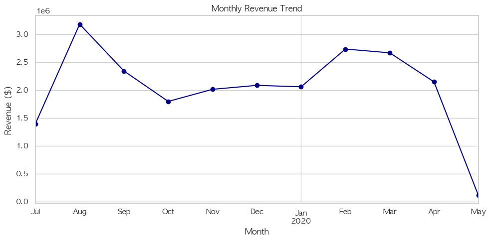

```python
# Ensure datetime is parsed correctly
long_df['datetime'] = pd.to_datetime(long_df['datetime'])

# Group by month and calculate total revenue
monthly_revenue = (
    long_df
    .groupby(long_df['datetime'].dt.to_period("M"))['total_revenue']
    .sum()
)

# Optional: Convert index back to timestamp for plotting
monthly_revenue.index = monthly_revenue.index.to_timestamp()

# Plot
monthly_revenue.plot(kind='line', marker='o', figsize=(10, 5), color='darkblue')
plt.title("Monthly Revenue Trend")
plt.xlabel("Month")
plt.ylabel("Revenue ($)")
plt.grid(True)
plt.tight_layout()
plt.savefig("monthly_revenue_trend.png", dpi=300)
plt.show()
```

```python
# KPI Summary
total_revenue = long_df['total_revenue'].sum()
total_quantity = long_df['quantity'].sum()
average_order_value = round(total_revenue / total_quantity, 2)

kpi_summary = pd.DataFrame({
    "Metric": ["Total Revenue", "Total Quantity", "Average Order Value"],
    "Value": [f"${total_revenue:,.2f}", f"{int(total_quantity)}", f"${average_order_value}"]
})

print(kpi_summary)
```

```
                Metric           Value
0        Total Revenue  $22,538,700.00
1       Total Quantity            5404
2  Average Order Value        $4170.74
```

```python
top_places = place_revenue.reset_index().sort_values(by='total_revenue', ascending=False)
top_places.columns = ['Location', 'Total Revenue']
top_places['Total Revenue'] = top_places['Total Revenue'].map("${:,.2f}".format)

print(top_places.head(10))
```

```
           Location  Total Revenue
18       Dong-myeon  $3,669,900.00
17          Unknown  $2,739,400.00
16  Hupyeong 3-dong  $2,022,300.00
15  Hupyeong 2-dong  $1,961,100.00
14  Hupyeong 1-dong  $1,792,100.00
13      Seoksa-dong  $1,654,700.00
12      Toegye-dong  $1,591,800.00
11     Hyoja 2-dong  $1,373,400.00
10      Soyang-dong  $1,127,700.00
9      Sinsa-u-dong    $812,100.00
```

## Step 11: Final Insights & Business Recommendations

After analyzing the local business sales data, here are the key takeaways I uncovered:

### Top Items by Quantity vs Revenue

- **Angbutter** had the highest quantity sold and also brought in the highest revenue overall, so it's the store’s strongest performer.
- **Croissant** was ranked second in both quantity and revenue, showing consistent customer demand.
- **Pandoro** and **Wiener** sold fewer units but brought in high revenue, which indicated premium pricing or higher margins.

### Revenue by Location

- **Dong-myeon** leads with over **$3.6M** in revenue.
- **Hupyeong 3-dong** and **Hupyeong 2-dong** also performed strongly.
- Some locations clearly outperformed others in total revenue.
- This can guide decisions on where to focus marketing or where to expand.

### Monthly Revenue Trend

A time series analysis revealed:

- Peak revenue occurred in **August**, with strong follow-up months in **February–March**.
- **May** shows a steep decline, possibly indicating seasonality or a data gap.

### KPI Summary

| Metric | Value |
| --- | --- |
| **Total Revenue** | $22,538,700 |
| **Total Quantity Sold** | 5,404 |
| **Average Order Value** | $4,170.74 |

## Next Steps / Business Actions

Based on these findings, I’d recommend:

- **Doubling down on best-selling items** (like angbutter and croissants).
- **Planning events or promotions on high-traffic days** (Weekends).
- **Targeting top-performing locations** for new product launches or ads.
- **Reviewing underperforming items/locations** for optimization or removal.
- Plan big promos or product drops around months like **August** and **February**.
- Investigate potential causes of May's dip.

This analysis gives the business clear, data-driven insights to help improve operations, boost sales, and better serve customers.